# HDS5230 Week02-R Programming Notebook

```r
#Install packages
install.packages("doParallel")
```

```
Error in install.packages : Updating loaded packages
```

```r
install.packages("foreach")
```

```
Error in install.packages : Updating loaded packages
```

```r
install.packages("randomForest")
```

```
Error in install.packages : Updating loaded packages
```

```r
install.packages("broom")
```

```
Error in install.packages : Updating loaded packages
```

```r
install.packages("data.table")
```

```
Error in install.packages : Updating loaded packages
```

```r
#load the libraries
library(randomForest)
library(MASS)
library(foreach)
library(parallel)
library(doParallel)
library(ggplot2)
library(data.table)
library(microbenchmark)
library(profvis)
library(broom)
```

```r
Boston
```

|  | crim | zn | indus | chas | nox | rm | age | dis | rad | tax | ptratio | black | lstat | medv |
| --- | --- | --- | --- | --- | --- | --- | --- | --- | --- | --- | --- | --- | --- | --- |
| 1 | 0.00632 | 18.0 | 2.31 | 0 | 0.5380 | 6.575 | 65.2 | 4.0900 | 1 | 296 | 15.3 | 396.90 | 4.98 | 24.0 |
| 2 | 0.02731 | 0.0 | 7.07 | 0 | 0.4690 | 6.421 | 78.9 | 4.9671 | 2 | 242 | 17.8 | 396.90 | 9.14 | 21.6 |
| 3 | 0.02729 | 0.0 | 7.07 | 0 | 0.4690 | 7.185 | 61.1 | 4.9671 | 2 | 242 | 17.8 | 392.83 | 4.03 | 34.7 |
| 4 | 0.03237 | 0.0 | 2.18 | 0 | 0.4580 | 6.998 | 45.8 | 6.0622 | 3 | 222 | 18.7 | 394.63 | 2.94 | 33.4 |
| 5 | 0.06905 | 0.0 | 2.18 | 0 | 0.4580 | 7.147 | 54.2 | 6.0622 | 3 | 222 | 18.7 | 396.90 | 5.33 | 36.2 |
| 6 | 0.02985 | 0.0 | 2.18 | 0 | 0.4580 | 6.430 | 58.7 | 6.0622 | 3 | 222 | 18.7 | 394.12 | 5.21 | 28.7 |
| 7 | 0.08829 | 12.5 | 7.87 | 0 | 0.5240 | 6.012 | 66.6 | 5.5605 | 5 | 311 | 15.2 | 395.60 | 12.43 | 22.9 |
| 8 | 0.14455 | 12.5 | 7.87 | 0 | 0.5240 | 6.172 | 96.1 | 5.9505 | 5 | 311 | 15.2 | 396.90 | 19.15 | 27.1 |
| 9 | 0.21124 | 12.5 | 7.87 | 0 | 0.5240 | 5.631 | 100.0 | 6.0821 | 5 | 311 | 15.2 | 386.63 | 29.93 | 16.5 |
| 10 | 0.17004 | 12.5 | 7.87 | 0 | 0.5240 | 6.004 | 85.9 | 6.5921 | 5 | 311 | 15.2 | 386.71 | 17.10 | 18.9 |

[output cut: 496 more lines]

### 1. Generate 100 bootstrapped sample of subsets of rows from the Boston dataset and fit a GLM on each of the samples. Perform this serially, that is, fitting of the model on the second bootstrapped sample should happen after the first model has been fit. Use medv as the outcome (which means, you would be fitting regression GLMs).

```r
Rprof('Serial_Bootstrap')
set.seed(31)
num_samples <- 100
bootstrap_samples <- foreach(i = 1:num_samples) %do% {
  Boston[sample(1:nrow(Boston), replace = TRUE), ]
}
Rprof(NULL)

summaryRprof('Serial_Bootstrap')
```

|  | self.time | self.pct | total.time | total.pct |
| --- | --- | --- | --- | --- |
| "tryCatch" | 0.02 | 33.33 | 0.06 | 100.00 |
| "%in%" | 0.02 | 33.33 | 0.02 | 33.33 |
| "f" | 0.02 | 33.33 | 0.02 | 33.33 |

|  | total.time | total.pct | self.time | self.pct |
| --- | --- | --- | --- | --- |
| "tryCatch" | 0.06 | 100.00 | 0.02 | 33.33 |
| "doTryCatch" | 0.06 | 100.00 | 0.00 | 0.00 |
| "tryCatchList" | 0.06 | 100.00 | 0.00 | 0.00 |
| "tryCatchOne" | 0.06 | 100.00 | 0.00 | 0.00 |
| "%do%" | 0.04 | 66.67 | 0.00 | 0.00 |
| "e$fun" | 0.04 | 66.67 | 0.00 | 0.00 |
| "%in%" | 0.02 | 33.33 | 0.02 | 33.33 |
| "f" | 0.02 | 33.33 | 0.02 | 33.33 |
| ".rs.callAs" | 0.02 | 33.33 | 0.00 | 0.00 |
| "[" | 0.02 | 33.33 | 0.00 | 0.00 |

[output cut: 9 more lines]

```
$sample.interval
[1] 0.02

$sampling.time
[1] 0.06
```

```r
#fitting the model to the bootstrapped samples
Rprof('Serial_Bootstrap_models')
bootstrap_models <- foreach(sample_data = bootstrap_samples) %do% {
  glm(medv ~ ., data = sample_data, family = gaussian())
}
Rprof(NULL)

summaryRprof('Serial_Bootstrap_models')
```

|  | self.time | self.pct | total.time | total.pct |
| --- | --- | --- | --- | --- |
| ".Call" | 0.06 | 21.43 | 0.06 | 21.43 |
| "tryCatchOne" | 0.02 | 7.14 | 0.28 | 100.00 |
| "glm.fit" | 0.02 | 7.14 | 0.08 | 28.57 |
| ".External" | 0.02 | 7.14 | 0.02 | 7.14 |
| "c" | 0.02 | 7.14 | 0.02 | 7.14 |
| "deparse" | 0.02 | 7.14 | 0.02 | 7.14 |
| "getIterVal.containeriter" | 0.02 | 7.14 | 0.02 | 7.14 |
| "makepredictcall" | 0.02 | 7.14 | 0.02 | 7.14 |
| "model.extract" | 0.02 | 7.14 | 0.02 | 7.14 |
| "model.matrix.default" | 0.02 | 7.14 | 0.02 | 7.14 |

[output cut: 2 more lines]

|  | total.time | total.pct | self.time | self.pct |
| --- | --- | --- | --- | --- |
| "tryCatchOne" | 0.28 | 100.00 | 0.02 | 7.14 |
| "tryCatch" | 0.28 | 100.00 | 0.00 | 0.00 |
| "tryCatchList" | 0.28 | 100.00 | 0.00 | 0.00 |
| "doTryCatch" | 0.26 | 92.86 | 0.00 | 0.00 |
| "%do%" | 0.24 | 85.71 | 0.00 | 0.00 |
| "e$fun" | 0.24 | 85.71 | 0.00 | 0.00 |
| "eval" | 0.22 | 78.57 | 0.00 | 0.00 |
| "glm" | 0.20 | 71.43 | 0.00 | 0.00 |
| "glm.fit" | 0.08 | 28.57 | 0.02 | 7.14 |
| ".Call" | 0.06 | 21.43 | 0.06 | 21.43 |

[output cut: 41 more lines]

```
$sample.interval
[1] 0.02

$sampling.time
[1] 0.28
```

### 2. For each of the model, extract the (or a) statistic that represents model fit.

```r
Rprof('Serial_model_statistics')
model_fit_stats <- rbindlist(foreach(model = bootstrap_models) %do% {
  glance(model)
}, idcol = "Model")
Rprof(NULL)

summaryRprof('Serial_model_statistics')
```

|  | self.time | self.pct | total.time | total.pct |
| --- | --- | --- | --- | --- |
| "doTryCatch" | 0.02 | 25 | 0.08 | 100 |
| "map2_" | 0.02 | 25 | 0.02 | 25 |
| "stopifnot" | 0.02 | 25 | 0.02 | 25 |
| "warn_on_glm2" | 0.02 | 25 | 0.02 | 25 |

|  | total.time | total.pct | self.time | self.pct |
| --- | --- | --- | --- | --- |
| "doTryCatch" | 0.08 | 100 | 0.02 | 25 |
| "%do%" | 0.08 | 100 | 0.00 | 0 |
| "e$fun" | 0.08 | 100 | 0.00 | 0 |
| "rbindlist" | 0.08 | 100 | 0.00 | 0 |
| "tryCatch" | 0.08 | 100 | 0.00 | 0 |
| "tryCatchList" | 0.08 | 100 | 0.00 | 0 |
| "tryCatchOne" | 0.08 | 100 | 0.00 | 0 |
| "eval" | 0.04 | 50 | 0.00 | 0 |
| "glance" | 0.04 | 50 | 0.00 | 0 |
| "glance.glm" | 0.04 | 50 | 0.00 | 0 |

[output cut: 9 more lines]

```
$sample.interval
[1] 0.02

$sampling.time
[1] 0.08
```

### 3. Aggregate the model fit statistics across the 100 bootstrapped samples and plot the results. Additionally compute the mean and inter-quartile range values for these test statistics.

```r
Rprof('Serial_agg_statistics')
aggregate_stats <- data.frame(
  Metric = c("Mean_Null_Deviance", "Mean_LogLik", "Mean_AIC", "Mean_BIC",
             "Mean_Deviance", "Mean_df_null", "Mean_df_residual", "Mean_nobs"),
  Value = c(mean(model_fit_stats$null.deviance), mean(model_fit_stats$logLik), mean(model_fit_stats$AIC), mean(model_fit_stats$BIC), mean(model_fit_stats$deviance), mean(model_fit_stats$df.null), mean(model_fit_stats$df.residual), mean(model_fit_stats$nobs))
)
Rprof(NULL)

summaryRprof('Serial_agg_statistics')
```

|  | self.time | self.pct | total.time | total.pct |
| --- | --- | --- | --- | --- |
| "doTryCatch" | 0.02 | 100 | 0.02 | 100 |

|  | total.time | total.pct | self.time | self.pct |
| --- | --- | --- | --- | --- |
| "doTryCatch" | 0.02 | 100 | 0.02 | 100 |
| ".rs.callAs" | 0.02 | 100 | 0.00 | 0 |
| "Rprof" | 0.02 | 100 | 0.00 | 0 |
| "tryCatch" | 0.02 | 100 | 0.00 | 0 |
| "tryCatchList" | 0.02 | 100 | 0.00 | 0 |
| "tryCatchOne" | 0.02 | 100 | 0.00 | 0 |
| "withCallingHandlers" | 0.02 | 100 | 0.00 | 0 |

```
$sample.interval
[1] 0.02

$sampling.time
[1] 0.02
```

```r
aggregate_stats
```

| Metric | Value |
| --- | --- |
| Mean_Null_Deviance | 42707.474 |
| Mean_LogLik | -1488.094 |
| Mean_AIC | 3006.188 |
| Mean_BIC | 3069.586 |
| Mean_Deviance | 10701.777 |
| Mean_df_null | 505.000 |
| Mean_df_residual | 492.000 |
| Mean_nobs | 506.000 |

```r
summary(model_fit_stats)
```

```
     Model        null.deviance      df.null        logLik           AIC            BIC          deviance
 Min.   :  1.00   Min.   :32578   Min.   :505   Min.   :-1565   Min.   :2823   Min.   :2886   Min.   : 7395
 1st Qu.: 25.75   1st Qu.:40086   1st Qu.:505   1st Qu.:-1512   1st Qu.:2970   1st Qu.:3033   1st Qu.: 9879
 Median : 50.50   Median :42893   Median :505   Median :-1490   Median :3010   Median :3074   Median :10705
 Mean   : 50.50   Mean   :42707   Mean   :505   Mean   :-1488   Mean   :3006   Mean   :3070   Mean   :10702
 3rd Qu.: 75.25   3rd Qu.:44902   3rd Qu.:505   3rd Qu.:-1470   3rd Qu.:3054   3rd Qu.:3117   3rd Qu.:11664
 Max.   :100.00   Max.   :51574   Max.   :505   Max.   :-1397   Max.   :3160   Max.   :3223   Max.   :14384
  df.residual       nobs
 Min.   :492   Min.   :506
 1st Qu.:492   1st Qu.:506
 Median :492   Median :506
 Mean   :492   Mean   :506
 3rd Qu.:492   3rd Qu.:506
 Max.   :492   Max.   :506
```

### Plot of aggregate statistics

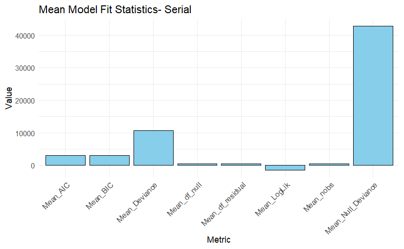

```r
#plots
library(ggplot2)
ggplot(aggregate_stats, aes(x = Metric, y = Value)) +
  geom_col(fill = "skyblue", color = "black") +
  theme_minimal() +
  labs(title = "Mean Model Fit Statistics- Serial", y = "Value", x = "Metric") +
  theme(axis.text.x = element_text(angle = 45, hjust = 1))
```

### Computing IQR

```r
Rprof('Serial_IQR_statistics')
#IQR statistics
IQR_stats <- model_fit_stats[, .(
  IQR_Null_Deviance = IQR(null.deviance),
  IQR_LogLik = IQR(logLik),
  IQR_AIC = IQR(AIC),
  IQR_BIC = IQR(BIC),
  IQR_Df_null=IQR(df.null),
  IQR_Df_residual= IQR(df.residual),
  IQR_Deviance = IQR(deviance),
  IQR_Nobs= IQR(nobs)
)]
Rprof(NULL)

summaryRprof('Serial_IQR_statistics')
```

|  | self.time | self.pct | total.time | total.pct |
| --- | --- | --- | --- | --- |
| "f" | 0.02 | 100 | 0.02 | 100 |

|  | total.time | total.pct | self.time | self.pct |
| --- | --- | --- | --- | --- |
| "f" | 0.02 | 100 | 0.02 | 100 |
| ".rs.callAs" | 0.02 | 100 | 0.00 | 0 |
| "doTryCatch" | 0.02 | 100 | 0.00 | 0 |
| "Rprof" | 0.02 | 100 | 0.00 | 0 |
| "tryCatch" | 0.02 | 100 | 0.00 | 0 |
| "tryCatchList" | 0.02 | 100 | 0.00 | 0 |
| "tryCatchOne" | 0.02 | 100 | 0.00 | 0 |
| "withCallingHandlers" | 0.02 | 100 | 0.00 | 0 |

```
$sample.interval
[1] 0.02

$sampling.time
[1] 0.02
```

### Parallelization setup

```r
cl <- makeCluster(4, type = "PSOCK")
registerDoParallel(cl)
```

### 4. Generate 100 bootstrapped sample of subsets of rows from the Boston dataset and fit a GLM on each of the samples. Perform this Parallely. Use medv as the outcome (which means, you would be fitting regression GLMs).

```r
Rprof('Parallel_bootstrap')
set.seed(31)
num_bootstraps <- 100
bootstrap_parallel <- foreach(i = 1:num_bootstraps, .packages = c("MASS")) %dopar% {
  Boston[sample(nrow(Boston), replace = TRUE), ]
}
Rprof(NULL)

summaryRprof('Parallel_bootstrap')
```

|  | self.time | self.pct | total.time | total.pct |
| --- | --- | --- | --- | --- |
| "unserialize" | 0.08 | 66.67 | 0.08 | 66.67 |
| "accumulate" | 0.02 | 16.67 | 0.02 | 16.67 |
| "getDoPar" | 0.02 | 16.67 | 0.02 | 16.67 |

|  | total.time | total.pct | self.time | self.pct |
| --- | --- | --- | --- | --- |
| "%dopar%" | 0.12 | 100.00 | 0.00 | 0.00 |
| "e$fun" | 0.10 | 83.33 | 0.00 | 0.00 |
| "unserialize" | 0.08 | 66.67 | 0.08 | 66.67 |
| "checkForRemoteErrors" | 0.06 | 50.00 | 0.00 | 0.00 |
| "clusterCall" | 0.06 | 50.00 | 0.00 | 0.00 |
| "FUN" | 0.06 | 50.00 | 0.00 | 0.00 |
| "lapply" | 0.06 | 50.00 | 0.00 | 0.00 |
| "recvData" | 0.06 | 50.00 | 0.00 | 0.00 |
| "recvData.SOCKnode" | 0.06 | 50.00 | 0.00 | 0.00 |
| "accumulate" | 0.02 | 16.67 | 0.02 | 16.67 |

[output cut: 11 more lines]

```
$sample.interval
[1] 0.02

$sampling.time
[1] 0.12
```

### Fitting the models

```r
Rprof('Parallel_bootstrap_model')
bootstrap_models_parallel <- foreach(sample_data = bootstrap_parallel, .packages = c("MASS")) %dopar% {
  glm(medv ~ ., data = sample_data, family = gaussian())
}
Rprof(NULL)

summaryRprof('Parallel_bootstrap_model')
```

|  | self.time | self.pct | total.time | total.pct |
| --- | --- | --- | --- | --- |
| "unserialize" | 1.34 | 89.33 | 1.36 | 90.67 |
| "sendCall" | 0.02 | 1.33 | 0.04 | 2.67 |
| "accumulate.iforeach" | 0.02 | 1.33 | 0.02 | 1.33 |
| "f" | 0.02 | 1.33 | 0.02 | 1.33 |
| "grepl" | 0.02 | 1.33 | 0.02 | 1.33 |
| "is.function" | 0.02 | 1.33 | 0.02 | 1.33 |
| "serialize" | 0.02 | 1.33 | 0.02 | 1.33 |
| "socketSelect" | 0.02 | 1.33 | 0.02 | 1.33 |
| "structure" | 0.02 | 1.33 | 0.02 | 1.33 |

|  | total.time | total.pct | self.time | self.pct |
| --- | --- | --- | --- | --- |
| "%dopar%" | 1.46 | 97.33 | 0.00 | 0.00 |
| "e$fun" | 1.46 | 97.33 | 0.00 | 0.00 |
| "clusterApplyLB" | 1.42 | 94.67 | 0.00 | 0.00 |
| "dynamicClusterApply" | 1.42 | 94.67 | 0.00 | 0.00 |
| "recvOneData" | 1.38 | 92.00 | 0.00 | 0.00 |
| "recvOneData.SOCKcluster" | 1.38 | 92.00 | 0.00 | 0.00 |
| "recvOneResult" | 1.38 | 92.00 | 0.00 | 0.00 |
| "unserialize" | 1.36 | 90.67 | 1.34 | 89.33 |
| "doTryCatch" | 0.06 | 4.00 | 0.00 | 0.00 |
| "tryCatch" | 0.06 | 4.00 | 0.00 | 0.00 |

[output cut: 29 more lines]

```
$sample.interval
[1] 0.02

$sampling.time
[1] 1.5
```

### Computing the stats of each model

```r
Rprof('Parallel_statistics')
model_stats_parallel <- foreach(model = bootstrap_models_parallel, .packages = c("broom", "data.table")) %dopar% {
  glance(model)[, c("df.null", "df.residual", "logLik", "AIC", "BIC",  "deviance", "null.deviance", "nobs")]
}
```

```
Error in stopifnot(is.character(filename), length(filename) == 1L) :
  reached elapsed time limit
```

```r
model_stats_parallel <- rbindlist(model_stats_parallel, idcol = "Model")
Rprof(NULL)

summaryRprof('Parallel_statistics')
```

|  | self.time | self.pct | total.time | total.pct |
| --- | --- | --- | --- | --- |
| "serialize" | 3.04 | 52.05 | 3.04 | 52.05 |
| "unserialize" | 0.74 | 12.67 | 0.74 | 12.67 |
| "sub" | 0.56 | 9.59 | 0.58 | 9.93 |
| "grepl" | 0.16 | 2.74 | 0.22 | 3.77 |
| "parse" | 0.10 | 1.71 | 0.22 | 3.77 |
| "file" | 0.08 | 1.37 | 0.08 | 1.37 |
| "paste" | 0.06 | 1.03 | 1.72 | 29.45 |
| ".Call" | 0.06 | 1.03 | 1.40 | 23.97 |
| "str" | 0.04 | 0.68 | 2.00 | 34.25 |
| "lapply" | 0.04 | 0.68 | 1.72 | 29.45 |

[output cut: 38 more lines]

|  | total.time | total.pct | self.time | self.pct |
| --- | --- | --- | --- | --- |
| "%dopar%" | 3.84 | 65.75 | 0.00 | 0.00 |
| "e$fun" | 3.84 | 65.75 | 0.00 | 0.00 |
| "clusterApplyLB" | 3.06 | 52.40 | 0.00 | 0.00 |
| "dynamicClusterApply" | 3.06 | 52.40 | 0.00 | 0.00 |
| "serialize" | 3.04 | 52.05 | 3.04 | 52.05 |
| "postNode" | 3.04 | 52.05 | 0.00 | 0.00 |
| "sendCall" | 3.04 | 52.05 | 0.00 | 0.00 |
| "sendData" | 3.04 | 52.05 | 0.00 | 0.00 |
| "sendData.SOCKnode" | 3.04 | 52.05 | 0.00 | 0.00 |
| "submit" | 3.04 | 52.05 | 0.00 | 0.00 |

[output cut: 123 more lines]

```
$sample.interval
[1] 0.02

$sampling.time
[1] 5.84
```

```r
summary(model_stats_parallel)
```

```
     Model           df.null     df.residual      logLik           AIC            BIC          deviance
 Min.   :  1.00   Min.   :505   Min.   :492   Min.   :-1568   Min.   :2871   Min.   :2934   Min.   : 8122
 1st Qu.: 25.75   1st Qu.:505   1st Qu.:492   1st Qu.:-1513   1st Qu.:2960   1st Qu.:3023   1st Qu.: 9685
 Median : 50.50   Median :505   Median :492   Median :-1494   Median :3018   Median :3081   Median :10866
 Mean   : 50.50   Mean   :505   Mean   :492   Mean   :-1491   Mean   :3012   Mean   :3075   Mean   :10829
 3rd Qu.: 75.25   3rd Qu.:505   3rd Qu.:492   3rd Qu.:-1465   3rd Qu.:3056   3rd Qu.:3119   3rd Qu.:11716
 Max.   :100.00   Max.   :505   Max.   :492   Max.   :-1420   Max.   :3166   Max.   :3230   Max.   :14575
 null.deviance        nobs
 Min.   :34537   Min.   :506
 1st Qu.:40438   1st Qu.:506
 Median :43685   Median :506
 Mean   :43584   Mean   :506
 3rd Qu.:46192   3rd Qu.:506
 Max.   :51652   Max.   :506
```

### Aggregating the statistics

```r
Rprof('Parallel_agg_statistics')
aggregate_stats_parallel <- foreach(metric = names(model_stats_parallel)[-1], .combine = rbind, .packages = "data.table") %dopar% {
  data.frame(Metric = paste0("Mean_", metric), Value = mean(model_stats_parallel[[metric]], na.rm = TRUE))
}
Rprof(NULL)

summaryRprof('Parallel_agg_statistics')
```

|  | self.time | self.pct | total.time | total.pct |
| --- | --- | --- | --- | --- |
| "unserialize" | 0.02 | 100 | 0.02 | 100 |

|  | total.time | total.pct | self.time | self.pct |
| --- | --- | --- | --- | --- |
| "unserialize" | 0.02 | 100 | 0.02 | 100 |
| "%dopar%" | 0.02 | 100 | 0.00 | 0 |
| "checkForRemoteErrors" | 0.02 | 100 | 0.00 | 0 |
| "clusterCall" | 0.02 | 100 | 0.00 | 0 |
| "e$fun" | 0.02 | 100 | 0.00 | 0 |
| "FUN" | 0.02 | 100 | 0.00 | 0 |
| "lapply" | 0.02 | 100 | 0.00 | 0 |
| "recvData" | 0.02 | 100 | 0.00 | 0 |
| "recvData.SOCKnode" | 0.02 | 100 | 0.00 | 0 |

```
$sample.interval
[1] 0.02

$sampling.time
[1] 0.02
```

### IQR stats

```r
Rprof('Parallel_IQR')
IQR_stats_parallel <- foreach(metric = names(model_stats_parallel)[-1], .combine = rbind, .packages = "data.table") %dopar% {
  data.frame(Metric = paste0("IQR_", metric), Value = IQR(model_stats_parallel[[metric]], na.rm = TRUE))
}
Rprof(NULL)

summaryRprof('Parallel_IQR')
```

|  | self.time | self.pct | total.time | total.pct |
| --- | --- | --- | --- | --- |
| "length" | 0.02 | 50 | 0.02 | 50 |
| "paste" | 0.02 | 50 | 0.02 | 50 |

|  | total.time | total.pct | self.time | self.pct |
| --- | --- | --- | --- | --- |
| "doTryCatch" | 0.04 | 100 | 0.00 | 0 |
| "tryCatch" | 0.04 | 100 | 0.00 | 0 |
| "tryCatchList" | 0.04 | 100 | 0.00 | 0 |
| "tryCatchOne" | 0.04 | 100 | 0.00 | 0 |
| "length" | 0.02 | 50 | 0.02 | 50 |
| "paste" | 0.02 | 50 | 0.02 | 50 |
| "%dopar%" | 0.02 | 50 | 0.00 | 0 |
| "...elt" | 0.02 | 50 | 0.00 | 0 |
| ".rs.describeObject" | 0.02 | 50 | 0.00 | 0 |
| ".rs.valueContents" | 0.02 | 50 | 0.00 | 0 |

[output cut: 24 more lines]

```
$sample.interval
[1] 0.02

$sampling.time
[1] 0.04
```

```r
IQR_stats_parallel
```

| Metric | Value |
| --- | --- |
| IQR_df.null | 0.00000 |
| IQR_df.residual | 0.00000 |
| IQR_logLik | 48.16474 |
| IQR_AIC | 96.32948 |
| IQR_BIC | 96.32948 |
| IQR_deviance | 2031.01958 |
| IQR_null.deviance | 5754.05464 |
| IQR_nobs | 0.00000 |

### Plot the aggregate stats

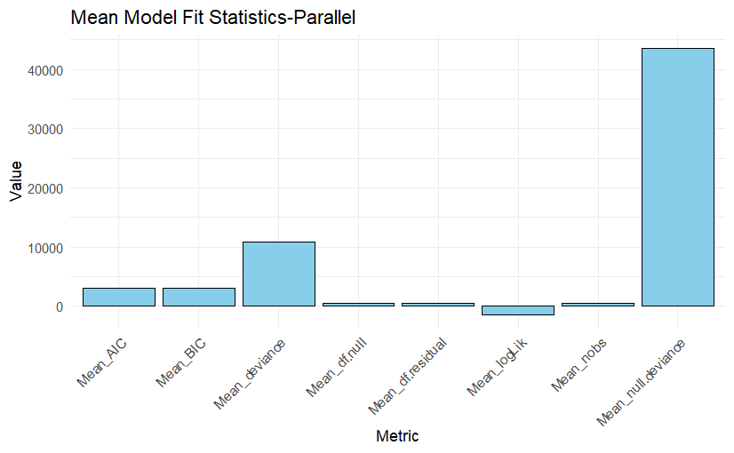

```r
plot_data_parallel <- foreach(i = 1:nrow(aggregate_stats_parallel), .combine = rbind, .packages = "data.table") %dopar% {
  data.frame(Metric = aggregate_stats_parallel$Metric[i], Value = aggregate_stats_parallel$Value[i])
}

ggplot(plot_data_parallel, aes(x = Metric, y = Value)) +
  geom_col(fill = "skyblue", color = "black") +
  theme_minimal() +
  labs(title = "Mean Model Fit Statistics-Parallel", y = "Value", x = "Metric") +
  theme(axis.text.x = element_text(angle = 45, hjust = 1))
```

```r
stopCluster(cl)
```

### 5. Compare the results of serial and parallel execution along the following dimensions:

### 5.1. Are the distributions of the model fit statistics similar or different?

The distribution of model fit statistics for both of the executions are very similar overall. Parallel execution shows slightly more variability in null deviance, logLik, AIC, BIC, and deviance. df.null, nobs, and df.residuals remain almost identical across methods.

Based on the aggregate test statistics plots, the distribution of the metrics appear similar between serial and parallel execution. The method of computation does not introduce significant differences in the statistical outputs, confirming that parallelization may impact execution time but not the statistical results.

### 5.2. Are the execution times for the serial and parallel approaches same or different?

```r
#serial execution microbenchmarking

set.seed(31)
num_samples <- 100
timing_results_serial <- microbenchmark(
  Bootstrap_Samples = {
    bootstrap_samples <- foreach(i = 1:num_samples) %do% {
      Boston[sample(1:nrow(Boston), replace = TRUE), ]
    }
  },
  Model_Fitting = {
    bootstrap_models <- foreach(sample_data = bootstrap_samples) %do% {
      glm(medv ~ ., data = sample_data, family = gaussian())
    }
  },
  Extract_Statistics = {
    model_fit_stats <- rbindlist(foreach(model = bootstrap_models) %do% {
      glance(model)
    }, idcol = "Model")
  },
  Aggregate_Statistics = {
    aggregate_stats <- data.frame(
      Metric = c("Mean_Null_Deviance", "Mean_LogLik", "Mean_AIC", "Mean_BIC",
                 "Mean_Deviance", "Mean_df_null", "Mean_df_residual", "Mean_nobs"),
      Value = c(mean(model_fit_stats$null.deviance), mean(model_fit_stats$logLik),
                mean(model_fit_stats$AIC), mean(model_fit_stats$BIC),
                mean(model_fit_stats$deviance), mean(model_fit_stats$df.null),
                mean(model_fit_stats$df.residual), mean(model_fit_stats$nobs))
    )
  },
  Compute_IQR = {
    IQR_stats <- model_fit_stats[, .(
      IQR_Null_Deviance = IQR(null.deviance),
      IQR_LogLik = IQR(logLik),
      IQR_AIC = IQR(AIC),
      IQR_BIC = IQR(BIC),
      IQR_Df_null = IQR(df.null),
      IQR_Df_residual = IQR(df.residual),
      IQR_Deviance = IQR(deviance),
      IQR_Nobs = IQR(nobs)
    )]
  },

  times = 10
)
timing_results_serial
```

```
Unit: microseconds
```

| expr | min | lq | mean | median | uq | max | neval | cld |
| --- | --- | --- | --- | --- | --- | --- | --- | --- |
| Bootstrap_Samples | 48209.3 | 61567.1 | 77041.22 | 76067.90 | 79037.9 | 127277.7 | 10 | a |
| Model_Fitting | 327901.0 | 356413.9 | 407340.78 | 379568.30 | 414552.2 | 674967.4 | 10 | b |
| Extract_Statistics | 78844.1 | 86210.4 | 112404.04 | 108131.40 | 122614.2 | 201559.7 | 10 | a |
| Aggregate_Statistics | 296.1 | 308.9 | 477.80 | 405.25 | 623.9 | 920.4 | 10 | c |
| Compute_IQR | 1105.4 | 1449.1 | 2077.65 | 1926.80 | 2237.8 | 4559.5 | 10 | c |

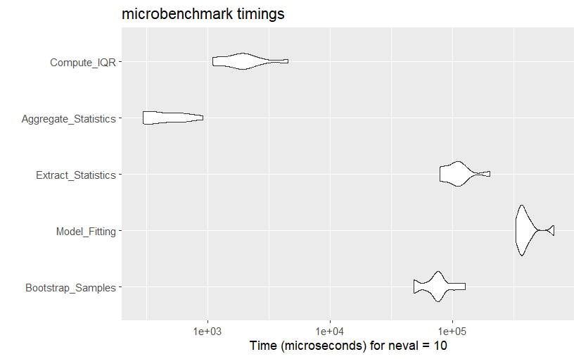

```r
autoplot(timing_results_serial)
```

```r
cl <- makeCluster(4, type = "PSOCK")
registerDoParallel(cl)
```

```r
# Parallel execution microbenchmarking
set.seed(31)
num_bootstraps <- 100
num_cores <- detectCores() - 1
cl <- makeCluster(num_cores)
registerDoParallel(cl)
timing_results_parallel <- microbenchmark(
  Bootstrap_Samples_Parallel = {
    bootstrap_parallel <- foreach(i = 1:num_bootstraps, .packages = c("MASS")) %dopar% {
      Boston[sample(nrow(Boston), replace = TRUE), ]
    }
  },
  Model_Fitting_Parallel = {
    bootstrap_models_parallel <- foreach(sample_data = bootstrap_parallel, .packages = c("MASS")) %dopar% {
      glm(medv ~ ., data = sample_data, family = gaussian())
    }
  },
  Extract_Statistics_Parallel = {
    model_stats_parallel <- foreach(model = bootstrap_models_parallel, .packages = c("broom", "data.table")) %dopar% {
      glance(model)[, c("df.null", "df.residual", "logLik", "AIC", "BIC",  "deviance", "null.deviance", "nobs")]
    }
    model_stats_parallel <- rbindlist(model_stats_parallel, idcol = "Model")
  },
  Aggregate_Statistics_Parallel = {
    aggregate_stats_parallel <- foreach(metric = names(model_stats_parallel)[-1], .combine = rbind, .packages = "data.table") %dopar% {
      data.frame(Metric = paste0("Mean_", metric), Value = mean(model_stats_parallel[[metric]], na.rm = TRUE))
    }
  },
  Compute_IQR_Parallel = {
    IQR_stats_parallel <- foreach(metric = names(model_stats_parallel)[-1], .combine = rbind, .packages = "data.table") %dopar% {
      data.frame(Metric = paste0("IQR_", metric), Value = IQR(model_stats_parallel[[metric]], na.rm = TRUE))
    }
  },
  times = 10
)
timing_results_parallel
```

```
Unit: milliseconds
```

| expr | min | lq | mean | median | uq | max | neval | cld |
| --- | --- | --- | --- | --- | --- | --- | --- | --- |
| Bootstrap_Samples_Parallel | 58.0702 | 72.6962 | 83.58898 | 78.71495 | 94.5383 | 118.7404 | 10 | a |
| Model_Fitting_Parallel | 644.7267 | 976.5640 | 1897.65426 | 1921.55810 | 2378.1741 | 4096.3062 | 10 | b |
| Extract_Statistics_Parallel | 2219.1701 | 3066.1451 | 3469.36829 | 3379.53730 | 3734.4508 | 4990.7725 | 10 | c |
| Aggregate_Statistics_Parallel | 7.8848 | 9.4865 | 12.17954 | 10.53275 | 15.2661 | 19.7433 | 10 | a |
| Compute_IQR_Parallel | 9.2214 | 10.3444 | 37.50295 | 16.64080 | 20.5969 | 235.5565 | 10 | a |

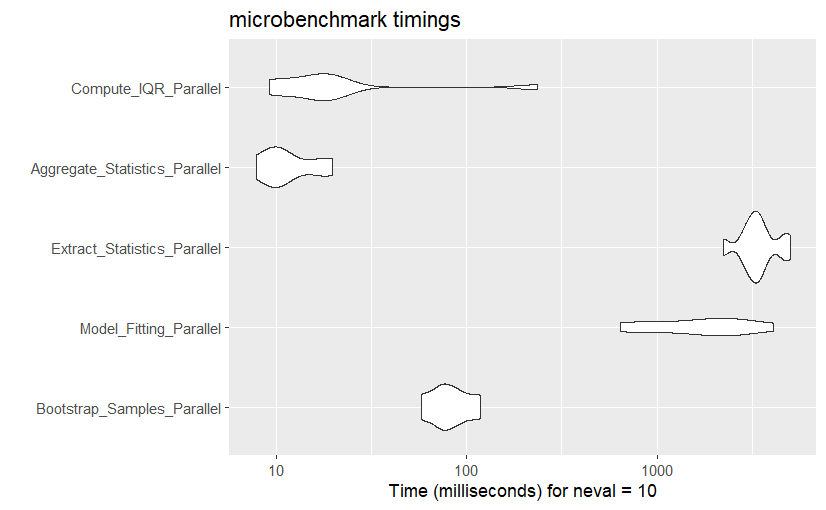

```r
autoplot(timing_results_parallel)
```

```r
stopCluster(cl)
```

```r
#rm(list=ls())
```